# Latent profiles of destructive and laissez-faire leadership in Chilean salaried workers — reproducible analysis

Reproducible R workflow for the latent class analysis (LCA) of the Constructive-Destructive Leadership Scale (FONDECYT 1170239 survey), using 13 of its 14 items (item 3, the negatively worded laissez-faire item, excluded). Produces the class enumeration (Table 1), item-response probabilities (Table 3), survey-weighted profile characteristics with medians (Table 2), the bias-adjusted three-step associations – maximum-likelihood odds ratios (Table S1) and marginal predicted probabilities (Table S2) – and the naive-vs-BCH sensitivity analysis (Table S3), together with Figures 1-2.

Author

Andres Gonzalez Santa Cruz

Published

September 7, 2026

# Overview

This notebook produces the general-sample analysis from the existing processed FONDECYT 1170239 input file. The reader directory places it alongside the hospital comparison, adjusted associations, sensitivities, and figures. The upstream construction of this processed input is not implemented here. It is organized as:

| Output | Section |
| --- | --- |
| **Table 1** — class enumeration (logL, AIC, BIC, entropy, BLRT) | *Class enumeration* |
| **Figure 1** — enumeration scree (AIC/BIC/CAIC/SABIC, BLRT, entropy) | *Figure 1* |
| **Table 3** + **Figure 2** — item-response probabilities | *Four-class model* |
| **Table 2** — survey-weighted profile characteristics (medians for continuous) | *Table 2* |
| **Table S1** — ML three-step odds ratios (ref = C1 Constructive) | *Table S1* |
| **Table S2** — marginal predicted probabilities by covariate level | *Table S2* |
| **Table S3** — sensitivity: naive vs BCH | *Table S3* |

**Estimators.** The measurement model is fitted with `glca` (as in the manuscript). Profile membership is related to covariates with two *bias-adjusted three-step* estimators that correct for classification error:

- **Maximum-likelihood (ML) three-step** — used for the odds ratios (Table S1) and the marginal predicted probabilities (Table S2). It maximises $\prod_i \sum_t \pi_t(z_i;\beta)\,P(W{=}w_i\mid X{=}t)$, where $W$ is the modal class, $P(W\mid X)$ is the (fixed) classification matrix from the measurement step, and $\pi_t(z;\beta)$ is a multinomial logit. No negative weights arise, so the logit is well behaved. *Implemented from scratch below* (`ml3step()`).
- **Bolck-Croon-Hagenaars (BCH)** — used for the naive-vs-adjusted sensitivity analysis (Table S3) and as the bias-adjusted means/proportions. *Implemented below* (`bch_setup()`).

**Configuration and reproducibility.** The variable mapping below is complete for the supplied input. Set `LCA_RAW_PATH` to use the same input on another computer; otherwise the notebook looks in this directory, then the documented Drive locations. An existing `lca_results.rds` is reused only after measurement-input alignment checks. Set `LCA_REFIT=1` for a fresh 4,000-start enumeration and bootstrap LRT. Without an existing bundle, the full estimation runs automatically. Table 2, the existing three-step analyses, and exports are regenerated on every render. See EXPORTS.md for the numeric tables and reusable private bundle.

```r
rm(list = ls()); gc()

required_packages <- c(
  # data wrangling
  "dplyr", "tidyr", "tibble", "purrr", "readr", "haven", "forcats", "stringr", "janitor", "rlang",
  # latent class analysis
  "glca", "poLCA",
  # survey-weighted estimation + simulation
  "survey", "MASS",
  # parallel backend for the enumeration fits + bootstrap LRT
  "future", "furrr",
  # multinomial logit (used for checks)
  "nnet",
  # plotting
  "ggplot2", "patchwork", "scales",
  # tables / output
  "knitr", "kableExtra", "digest"
)

missing_packages <- required_packages[!vapply(required_packages, requireNamespace, logical(1), quietly = TRUE)]
if (length(missing_packages)) stop("Install required R packages before rendering: ", paste(missing_packages, collapse = ", "))
invisible(lapply(required_packages, function(pkg)
  suppressPackageStartupMessages(library(pkg, character.only = TRUE))))
source("R/leadership_table2.R")
source("R/load_leadership_results.R")
reuse_measurement <- file.exists("lca_results.rds") && Sys.getenv("LCA_REFIT", "0") != "1"
saved_measurement <- if (reuse_measurement) readRDS("lca_results.rds") else NULL
render_started_utc <- format(Sys.time(), tz = "UTC", usetz = TRUE)

set.seed(2125)            # 2125 = lucky seed; used for every stochastic step
options(scipen = 999)

## Random starting values for every glca() measurement fit (local-maxima
## safeguard). The reported models below use this many random starts; the
## bootstrap LRT (gofglca) is unaffected -- it warm-starts each replicate from
## the fitted parameters with a single EM run. Lower n_init (e.g. 50) for quick
## drafts and restore 4000 for the final, reportable run.
n_init <- 4000
```

```
          used (Mb) gc trigger (Mb) max used (Mb)
Ncells  594674 31.8    1356091 72.5   685954 36.7
Vcells 1105956  8.5    8388608 64.0  1877217 14.4
```

## Data and variable mapping

The `vars` list maps analysis names to verified columns in the supplied file. Required columns and positive survey weights are checked before estimation. Leadership items are the ordinal variables `lid_des1 … lid_des14` (1 = never … 4 = almost always/always), of which **13** enter the LCA — item 3 (`lid_des3`) is excluded.

```r
## (i) ------------------------------------------------------------ FILE PATH
## Resuelve la ruta automaticamente detectando la letra de unidad de Google
## Drive: prueba H:, G: y C: y usa la primera raiz donde el archivo exista.
## Asi el .qmd no se rompe si Google Drive cambia de unidad o se abre en otro PC.
## Solo mantienes 'rel' (ruta RELATIVA a la raiz de Google Drive).
resolve_drive_path <- function(rel,
    roots = c("H:/My Drive", "G:/Mi unidad", "C:/Users/andre/Google Drive")) {
  rel <- gsub("\\\\", "/", rel)
  for (r in roots) {
    p <- file.path(r, rel)
    if (file.exists(p)) return(p)
  }
  stop("No se encontro el archivo en ninguna raiz conocida:\n  ",
       paste(file.path(roots, rel), collapse = "\n  "),
       "\nAgrega la raiz correcta a 'roots'.")
}

## Lector segun extension del archivo (.dta -> read_dta, .sav -> read_sav, etc.)
read_any <- function(path) {
  switch(tolower(tools::file_ext(path)),
    dta = haven::read_dta(path),
    sav = haven::read_sav(path),
    rds = readRDS(path),
    csv = readr::read_csv(path, show_col_types = FALSE),
    stop("Extension no soportada: ", tools::file_ext(path)))
}
## La base .rds se genero (en otra sesion) con:
##   rio::export(BD_2020_input3_match_not_miss, "BD_2020_input3_match_not_miss.rds")
raw_path <- Sys.getenv("LCA_RAW_PATH", "")
if (!nzchar(raw_path)) {
  local_input <- "BD_2020_input3_match_not_miss.rds"
  raw_path <- if (file.exists(local_input)) local_input else resolve_drive_path(
    "DOCUMENTOS/6.TESIS 2018/LCA NAQ/BD_2020_input3_match_not_miss.rds")
}
if (!file.exists(raw_path)) stop("LCA_RAW_PATH does not point to an existing input file.")
## Alternativas (bases procesadas en la carpeta del proyecto), si las prefieres:
# raw_path <- resolve_drive_path("DOCUMENTOS/6.TESIS 2018/LCA NAQ/culorg 06-04- BD_05_02_19 (BD_22_10_18_lab_cul_org2)_post modelos_finales2.dta")
message("Datos cargados desde: ", raw_path)
```

```
Datos cargados desde: BD_2020_input3_match_not_miss.rds
```

```r
raw <- read_any(raw_path) |> janitor::clean_names()   # LID_DES1..14 -> lid_des1..14
## (ii) ----------------------------------------------------- VARIABLE MAPPING
## Mapeo a las columnas REALES de BD_2020_input3_match_not_miss.rds. Las
## covariables vienen como FACTORES con etiquetas; abajo se construyen copias
## limpias: binarias 0/1 con 1 = expuesto (segun `yes_levels`) y continuas
## numericas (`cont_vars`). 'vars' solo documenta la columna de origen.
vars <- list(
  ## 13 leadership items (ordinal 1-4), CDLS item order lid_des1..14 with
  ## item 3 (lid_des3) EXCLUDED. lid_des3 -- "steers away from showing concern
  ## about results" -- is the negatively worded laissez-faire item; it is dropped
  ## from the LCA measurement model here, so 13 items enter every fit/figure.
  items  = paste0("lid_des", c(1:2, 4:14)),

  ## survey design
  weight = "weight",   # ponderador (continuo)
  strata = NA,         # no hay estrato muestral en esta base -> diseno solo-pesos
  psu    = NA,         # no hay conglomerado/PSU en esta base

  ## covariates for Tables 2 / S1-S3 (binary unless noted)
  age            = "a53",                  # CONTINUOUS: edad en anios (20-83)
  job_sat        = "satis",                # CONTINUOUS: suma satisfaccion laboral (0-20)
  sex_woman      = "a52",                  # 1 = "Women"
  eri            = "desbalance_dic",       # 1 = "Yes" (Effort-Reward Imbalance, ERI)
  naq_frequent   = "naq_a",                # 1 = "2" (cumple criterio Agervold de actos negativos)
  bully_self     = "autonaq",              # 1 = "Yes" (self-labeling bullied, 6m)
  sex_harass     = "acos_sex",             # 1 = "2" (acoso sexual, 12m)
  auditc_hazard  = "auditc",               # 1 = "Yes" (AUDIT-C de riesgo)
  no_union       = "org_sind",             # 1 = "Yes" (ausencia de sindicato)
  unpaid_care    = "carga_dom",            # 1 = "Yes" (cuidados no remunerados)
  no_secondary   = "educacion_media",      # 1 = "Yes" (no completo secundaria)
  small_wp       = "tamano_de_la_empresa", # 1 = "1 to 10" (lugar de 1-10 personas)
  customer_no    = "atpub",                # 1 = "Job w/o customer-facing tasks"
  econ_narrow    = "estrechez"             # 1 = "2" (estrechez economica)
)

## Covariables continuas (se copian como numericas, sin dicotomizar)
cont_vars <- c("age", "job_sat")

## Para cada covariable binaria: nivel(es) de texto que corresponden a "1 = expuesto".
## (Asi la direccion 0/1 queda explicita y auditable, sin depender del codigo 1/2.)
yes_levels <- list(
  sex_woman     = "Women",
  eri           = "Yes",
  naq_frequent  = "2",
  bully_self    = "Yes",
  sex_harass    = "2",
  auditc_hazard = "Yes",
  no_union      = "Yes",
  unpaid_care   = "Yes",
  no_secondary  = "Yes",
  small_wp      = "1 to 10",
  customer_no   = "Job w/o customer-facing tasks",
  econ_narrow   = "2"
)

## Build the analysis data frame -----------------------------------------
## Leadership items -> ordered factors with the SAME 4 levels (1..4).
## OJO: en esta base los items vienen codificados 0..3 (0 = nunca ... 3 = casi
## siempre/siempre). El resto del notebook asume 1..4, asi que se desplazan +1
## automaticamente si la base esta en base 0. (NO usar las versiones *_rec, que
## estan dicotomizadas 0/1, ni *_clus.)
required_columns <- unique(unlist(vars[!names(vars) %in% c("strata", "psu")]))
missing_columns <- setdiff(required_columns, names(raw))
if (length(missing_columns)) stop("Missing mapped columns: ", paste(missing_columns, collapse = ", "))
d <- raw
d$.source_row <- seq_len(nrow(d))
item_min <- suppressWarnings(min(vapply(vars$items,
              function(it) min(as.numeric(d[[it]]), na.rm = TRUE), numeric(1))))
shift <- if (is.finite(item_min) && item_min == 0) 1L else 0L
for (it in vars$items) {
  values <- as.numeric(d[[it]]) + shift
  if (any(!is.na(values) & !values %in% 1:4)) stop("Invalid ordinal codes in ", it)
  d[[it]] <- factor(values, levels = 1:4, ordered = TRUE)
}
if (shift == 1L) message("Items de liderazgo recodificados de 0-3 a 1-4 (+1).")

## --- helpers de coercion ------------------------------------------------
## Numerico robusto: sirve para factor-de-numeros y para labelled/numeric.
as_num <- function(x) {
  if (is.factor(x)) return(suppressWarnings(as.numeric(as.character(x))))
  as.numeric(haven::zap_labels(x))
}
## Binaria 0/1 desde un factor: 1 = nivel(es) en 'yes'. Los niveles de texto
## "NA"/"Not Apply" se tratan como perdidos (NA), no como 0.
to01 <- function(x, yes) {
  f <- as.character(haven::as_factor(x))
  f[f %in% c("NA", "Not Apply", "NaN", "")] <- NA
  if (!any(f %in% yes, na.rm = TRUE)) stop("No mapped exposed level found: ", paste(yes, collapse = ", "))
  out <- as.integer(f %in% yes)
  out[is.na(f)] <- NA_integer_
  out
}

## Continuas -> copia numerica
for (nm in cont_vars) d[[nm]] <- as_num(d[[ vars[[nm]] ]])
## Binarias -> copia 0/1 (1 = expuesto)
for (nm in names(yes_levels)) d[[nm]] <- to01(d[[ vars[[nm]] ]], yes_levels[[nm]])

## Survey weights are required; silently replacing them with 1 changes the estimand.
d$.w <- as_num(d[[vars$weight]])
if (any(!is.finite(d$.w) | d$.w <= 0)) stop("Survey weights must be finite and positive.")

## Keep complete cases on the 13 items AND on the measurement-model concomitant
## (sex_woman, used as ~sex_woman in item_f). glca does listwise deletion on its
## model frame, so if the concomitant had any NA, g4$posterior would have FEWER
## rows than d_lca and post4/modal4 would silently misalign with d_lca, the survey
## design and every covariate vector. Enforcing it here keeps everything aligned.
concomitant <- "sex_woman"   # RHS of item_f in the enumeration chunk
d_lca <- d[stats::complete.cases(d[, c(vars$items, concomitant)]), ]
cat("Rows total:", nrow(d), " | complete on 13 items + ", concomitant, ":", nrow(d_lca), "\n")
model_input_hash <- digest::digest(d_lca[, c(vars$items, concomitant), drop = FALSE], algo = "sha256")
measurement_validation <- if (reuse_measurement)
  validate_saved_measurement(saved_measurement, d_lca, vars$items, concomitant) else "Fresh measurement estimation."
cat(measurement_validation, "\n")
sample_flow <- tibble::tibble(
  stage = c("Input records", "Complete on 13 leadership items", "Complete on 13 items and sex"),
  n = c(nrow(d), sum(complete.cases(d[, vars$items])), nrow(d_lca)))
```

```
Rows total: 1995  | complete on 13 items +  sex_woman : 1847
Matched SHA-256 fingerprint of ordered measurement inputs.
```

```r
## Survey design for the weighted descriptives (Table 2).
## If strata/psu are not available, a weights-only design is used.
has <- function(k) !isTRUE(is.na(vars[[k]])) && vars[[k]] %in% names(d_lca)

if (has("strata") && has("psu")) {
  dsn <- svydesign(ids = as.formula(paste0("~", vars$psu)),
                   strata = as.formula(paste0("~", vars$strata)),
                   weights = ~.w, data = d_lca, nest = TRUE)
} else {
  dsn <- svydesign(ids = ~1, weights = ~.w, data = d_lca)
}
dsn
```

```
Independent Sampling design (with replacement)
svydesign(ids = ~1, weights = ~.w, data = d_lca)
```

## Helper functions

`relative_entropy()`, the classification matrix, **BCH** weights, and the from-scratch **ML three-step** estimator.

```r
## Relative entropy (0-1; higher = cleaner separation) from the posterior matrix.
relative_entropy <- function(post) {
  post <- as.matrix(post)
  n <- nrow(post); K <- ncol(post)
  e <- -sum(post * log(pmax(post, 1e-12)))
  1 - e / (n * log(K))
}

## Classification matrix D[t, w] = P(W = w | X = t), W = modal class.
class_matrix <- function(post, modal) {
  K <- ncol(post)
  ind <- outer(modal, 1:K, `==`) * 1            # n x K modal indicators
  A <- t(as.matrix(post)) %*% ind               # K x K : sum_i post[i,t] I(W=w)
  A / rowSums(A)                                 # rows (true t) sum to 1
}

## ---- BCH set-up: weight matrix bch[i, t] = (D^{-1})[t, w_i] -------------
## Bias-adjusted class statistics use column t of `bch` as weights.
bch_setup <- function(post, modal) {
  D <- class_matrix(post, modal)
  Dinv <- solve(D)
  bch <- t(Dinv[, modal])                        # n x K ; bch[i,t]=Dinv[t,w_i]
  list(D = D, Dinv = Dinv, w = bch)
}

## Bias-adjusted (BCH) weighted mean of a numeric x within each latent class.
## (Use for proportions of 0/1 variables and for the mean of a score.)
bch_class_mean <- function(x, bchw, sw = NULL) {
  x <- as.numeric(x); K <- ncol(bchw)
  if (is.null(sw)) sw <- rep(1, length(x))
  vapply(seq_len(K), function(t) {
    w <- bchw[, t] * sw
    sum(w * x, na.rm = TRUE) / sum(w[!is.na(x)])
  }, numeric(1))
}

## Naive (modal-assignment) mean of x within each class.
naive_class_mean <- function(x, modal, sw = NULL, K = max(modal)) {
  x <- as.numeric(x)
  if (is.null(sw)) sw <- rep(1, length(x))
  vapply(seq_len(K), function(t) {
    idx <- which(modal == t)
    sum(sw[idx] * x[idx], na.rm = TRUE) / sum(sw[idx][!is.na(x[idx])])
  }, numeric(1))
}

## ---- ML three-step (Vermunt 2010) for ONE covariate z ------------------
## Maximises  prod_i sum_t pi_t(z_i;b) * P(W=w_i | X=t),  reference class = 1.
## Returns coefficients, vcov, and per-class odds ratios (exp of the slope).
ml3step <- function(z, post, modal, sw = NULL, D = NULL) {
  post <- as.matrix(post); K <- ncol(post)
  if (is.null(sw)) sw <- rep(1, nrow(post))
  ## Classification matrix D[t,w]=P(W=w|X=t) is a FIXED property of the
  ## measurement step: compute it ONCE on the FULL sample (all rows of
  ## post/modal), BEFORE dropping NA on z. Computing it on the per-covariate
  ## complete-case subset would give each covariate a different D and would
  ## disagree with the BCH analysis (Table S3, which uses the full-sample D).
  if (is.null(D)) D <- class_matrix(post, modal)  # K x K, full measurement sample
  z <- as.numeric(z)
  ok <- !is.na(z)
  z <- z[ok]; modal <- modal[ok]; post <- post[ok, , drop = FALSE]; sw <- sw[ok]
  n <- length(z)   # rows AFTER dropping NA on z; must match z/sw or negll's
                   # outer(rep(1, n), a) is non-conformable when z has missings.
  Dw <- t(D[, modal])                            # n x K ; [i,t]=P(W=w_i|X=t)
                                                 # global D indexed by the subset modal
  negll <- function(par) {
    a <- c(0, par[seq(1, 2 * (K - 1), 2)])       # intercepts (a_1 = 0)
    b <- c(0, par[seq(2, 2 * (K - 1), 2)])       # slopes     (b_1 = 0)
    eta <- outer(rep(1, n), a) + outer(z, b)     # n x K
    eta <- eta - apply(eta, 1, max)              # stabilise
    pis <- exp(eta); pis <- pis / rowSums(pis)   # n x K class probs
    pw <- rowSums(pis * Dw)                       # P(W=w_i)
    -sum(sw * log(pmax(pw, 1e-12)))
  }
  fit <- optim(rep(0, 2 * (K - 1)), negll, method = "BFGS", hessian = TRUE)
  V <- tryCatch(solve(fit$hessian), error = function(e) matrix(NA, length(fit$par), length(fit$par)))
  b_idx <- seq(2, 2 * (K - 1), 2)
  b  <- fit$par[b_idx]
  se <- sqrt(diag(V))[b_idx]
  tibble::tibble(
    class = 2:K,
    OR    = exp(b),
    lo    = exp(b - 1.96 * se),
    hi    = exp(b + 1.96 * se)
  ) -> ors
  list(par = fit$par, V = V, K = K, ors = ors, conv = fit$convergence)
}

## Parametric-bootstrap marginal predicted probabilities P(X=t | z) at z=0 and
## z=1, with 95% CIs and the difference (pp). Draws beta ~ N(beta_hat, V).
ml3step_margins <- function(m, B = 2000) {
  K <- m$K; par <- m$par; V <- m$V
  draws <- MASS::mvrnorm(B, mu = par, Sigma = V)
  probs <- function(p, z) {
    a <- c(0, p[seq(1, 2 * (K - 1), 2)]); b <- c(0, p[seq(2, 2 * (K - 1), 2)])
    eta <- a + z * b; e <- exp(eta - max(eta)); e / sum(e)
  }
  p0 <- t(apply(draws, 1, probs, z = 0))         # B x K
  p1 <- t(apply(draws, 1, probs, z = 1))
  q <- function(M) apply(M, 2, quantile, c(.025, .5, .975))
  list(
    z0 = q(p0), z1 = q(p1),
    delta = apply(p1 - p0, 2, quantile, c(.025, .5, .975))
  )
}
```

## Table 1 — Class enumeration

Fits 2- to 10-class models with sex as the concomitant, 4,000 starts per model and 1,000 bootstrap replicates per LRT comparison. In reuse mode, the verified saved enumeration table is loaded without repeating estimation.

```r
# Report chunks always run. Only explicitly validated measurement results are reused.
n_lca <- nrow(d_lca)
if (reuse_measurement) {
  fit_tbl <- saved_measurement$fit_tbl
  nboot <- if (is.null(saved_measurement$nboot)) 1000L else saved_measurement$nboot
  cat("Reusing saved measurement estimates; no LCA or BLRT refitted.\n")
} else {
item_f <- as.formula(paste0("item(", paste(vars$items, collapse = ", "), ") ~ sex_woman"))
Kmax <- 10

## ---- Parallel backend -------------------------------------------------
## glca/gofglca are single-threaded, so on a multi-core machine the default
## (sequential) enumeration leaves ~all cores idle. We distribute the work
## ourselves across multisession workers: the k-model fits run concurrently,
## and the bootstrap LRT is split into (k x chunk) tasks so the 1000 replicates
## of EACH comparison genuinely span >= nchunks cores (see the BLRT block below).
## >= 8 workers as requested; capped at 16 to keep RAM in check (each worker is
## a separate R process holding its own copy of d_lca). gc() is called after the
## fits, after the bootstrap, and inside every worker once its chunk is done.
## detectCores() can return NA on some platforms/containers; fall back safely so
## n_workers is never NA (which would make plan() error and cascade-fail the run).
n_phys <- parallel::detectCores(logical = FALSE)
if (is.na(n_phys)) n_phys <- parallel::detectCores()
if (is.na(n_phys)) n_phys <- 4L
n_workers <- max(8L, min(n_phys - 2L, 16L))
future::plan(future::multisession, workers = n_workers)
message("Parallel enumeration on ", n_workers, " workers.")

## Fit 2..Kmax class models concurrently (fits[[1]] stays NULL).
## n.init = n_init (4000) random starts per model avoid local maxima. Two
## worker-side safeguards are needed precisely BECAUSE n.init is large:
##  (1) RNGkind("Mersenne-Twister"): furrr_options(seed = TRUE) switches each
##      worker to the L'Ecuyer-CMRG generator. glca() reseeds internally with
##      set.seed(seed), so under L'Ecuyer its 4000 random starts DIFFER from the
##      (validated) Mersenne-Twister ones -- and for the largest model (k = 10)
##      one L'Ecuyer start is degenerate: loglik -> NaN -> maxdiff -> NA ->
##      glca() errors with "missing value where TRUE/FALSE is needed". Forcing MT
##      makes every worker reproduce the well-behaved standalone fit. (This is
##      why n.init = 10 never failed: 10 starts didn't reach the bad one.)
##  (2) seed fallback 2125 -> 2126 -> ...: belt-and-suspenders. If some future
##      glca version / dataset still seeds a degenerate start, retry with the next
##      seed rather than crash the whole render. 2125 (the lucky seed) is used
##      whenever it works; with the MT fix above it works for every k here, so no
##      fallback is triggered and results stay exactly reproducible at 2125.
## n_init, item_f and d_lca are captured automatically as globals by furrr.
fits <- vector("list", Kmax)
fits[2:Kmax] <- furrr::future_map(2:Kmax, function(k) {
  RNGkind("Mersenne-Twister")
  g <- NULL
  for (s in 2125:2134) {
    g <- tryCatch(glca(item_f, data = d_lca, nclass = k, seed = s,
                       n.init = n_init, verbose = FALSE),
                  error = function(e) NULL)
    if (!is.null(g)) break
  }
  if (is.null(g)) stop("glca failed for nclass=", k, " across fallback seeds 2125-2134.")
  attr(g, "successful_seed") <- s
  g
}, .options = furrr::furrr_options(seed = TRUE, packages = "glca"))
gc()   # reclaim memory used while collecting the fits back to the main process

## Extract posterior matrix from a glca object (single group).
get_post <- function(g) {
  p <- g$posterior
  if (is.list(p)) p <- p[[1]]
  as.matrix(p)
}

## Defensive getter for gof scalars (slot names vary slightly by glca version;
## if these return NA, inspect str(fits[[4]]$gof) and adjust the candidates).
gof_get <- function(g, what) {
  gg <- g$gof
  cand <- switch(what,
    loglik = c("loglik", "logLik", "ll"),
    aic    = c("aic", "AIC"),
    bic    = c("bic", "BIC"))
  for (nm in cand) if (!is.null(gg[[nm]])) return(as.numeric(gg[[nm]])[1])
  NA_real_
}

n_lca <- nrow(d_lca)
fit_tbl <- purrr::map_dfr(2:Kmax, function(k) {
  g  <- fits[[k]]
  ll  <- gof_get(g, "loglik"); aic <- gof_get(g, "aic"); bic <- gof_get(g, "bic")
  np  <- (aic + 2 * ll) / 2                       # npar = (AIC + 2*logL)/2
  caic  <- -2 * ll + np * (log(n_lca) + 1)
  sabic <- -2 * ll + np * log((n_lca + 2) / 24)
  ## AWE (approximate weight of evidence; Banfield & Raftery 1993, Masyn 2013):
  ## -2logL + 2*npar*(3/2 + ln n). Like BIC/CAIC/SABIC, LOWER = better. (See the
  ## table note for the formula variant; this is the psychometric-standard one.)
  awe   <- -2 * ll + 2 * np * (1.5 + log(n_lca))
  post  <- get_post(g); modal <- max.col(post)
  ent   <- relative_entropy(post)
  ## Smallest class + AvePP from MODAL (most-likely) class membership.
  cl_n  <- as.integer(table(factor(modal, levels = 1:k)))      # modal class sizes
  avepp <- vapply(1:k, function(t)                             # AvePP_t per class
             if (any(modal == t)) mean(post[modal == t, t]) else NA_real_, numeric(1))
  tibble::tibble(Classes = k, logLik = ll, npar = np,
                 AIC = aic, BIC = bic, CAIC = caic, SABIC = sabic, AWE = awe,
                 Entropy = ent, `Mean AvePP` = mean(avepp, na.rm = TRUE),
                 `Smallest n` = min(cl_n), `Smallest %` = min(cl_n) / n_lca * 100)
})

## Approximate Bayes factor BF_{k,k+1} = exp((BIC_{k+1} - BIC_k)/2) (Masyn 2013):
## BF > 1 favours the k-class model over k+1 (>3 moderate, >10 strong evidence);
## undefined (NA) for the largest model, which has no k+1. Formatted at display.
bic_next  <- fit_tbl$BIC[match(fit_tbl$Classes + 1L, fit_tbl$Classes)]
fit_tbl$BF <- exp((bic_next - fit_tbl$BIC) / 2)

## ---- Bootstrap LRT, k vs k-1, parallelised across the 1000 replicates ----
## Approach B. Each comparison's nboot=1000 reps are split into `nchunks`
## independent chunks (distinct seeds); chunks for ALL k-comparisons are flat-
## mapped onto the workers (8 k x nchunks tasks), so the 1000 reps genuinely run
## across >=8 cores instead of one. Validated against gofglca on gss08: the
## p-value = mean(boot.GsqR >= observed Deviance) reproduces glca exactly, and
## pooling independent-seed chunks is statistically identical to one long run
## (the reps are i.i.d.). Per-chunk extractor pulls the observed LRT statistic
## from dtable[2,"Deviance"] and the bootstrap LRT vector from boot$boot.GsqR.
nboot   <- 1000
nchunks <- 8L                                  # >=8 -> the 1000 reps span >=8 cores per k
chunk_nb <- rep(nboot %/% nchunks, nchunks)    # reps per chunk (sums to nboot)
rem <- nboot %% nchunks; if (rem) chunk_nb[seq_len(rem)] <- chunk_nb[seq_len(rem)] + 1L

## Flat task grid: one row per (k-comparison, chunk). Distinct seed per chunk.
blrt_grid <- expand.grid(k = 3:Kmax, chunk = seq_len(nchunks), KEEP.OUT.ATTRS = FALSE)

blrt_chunk <- function(k, chunk, nb, seed) {
  go <- tryCatch(glca::gofglca(fits[[k - 1]], fits[[k]], test = "boot",
                               nboot = nb, seed = seed),
                 error = function(e) NULL)
  if (is.null(go)) return(list(k = k, obs = NA_real_, boot = numeric(0)))
  out <- list(k = k,
              obs  = as.numeric(go$dtable[2, "Deviance"]),        # observed LRT stat
              boot = as.numeric(go$boot$boot.GsqR[1, ]))          # bootstrap LRT reps
  rm(go); gc(verbose = FALSE)                  # free per-chunk memory inside worker
  out
}

chunk_res <- furrr::future_pmap(
  list(k = blrt_grid$k, chunk = blrt_grid$chunk),
  ## Unique seed per (k, chunk) -> every comparison draws an independent
  ## bootstrap stream (avoids correlated Monte-Carlo error across k).
  function(k, chunk) blrt_chunk(k, chunk, chunk_nb[chunk],
                                seed = (k - 3L) * nchunks + chunk),
  .options = furrr::furrr_options(seed = TRUE, packages = "glca",
                                  globals = c("fits", "chunk_nb", "nchunks", "blrt_chunk")))
future::plan(future::sequential)               # release workers
gc()                                           # tidy the main process

## Pool the chunks back per k and compute p = mean(pooled boot >= observed).
## obs (observed Deviance) is deterministic and identical across a k's chunks,
## so take it from the first chunk that succeeded (not strictly parts[[1]], which
## would drop the whole k if only that one chunk hit a transient failure).
blrt_p <- c(NA, sapply(3:Kmax, function(kk) {
  parts <- chunk_res[vapply(chunk_res, function(z) z$k, numeric(1)) == kk]
  obs   <- stats::na.omit(vapply(parts, function(z) z$obs, numeric(1)))[1]
  boot  <- unlist(lapply(parts, `[[`, "boot"))
  if (is.na(obs) || !length(boot)) NA_real_ else mean(boot >= obs)
}))
fit_tbl$`BLRT P` <- blrt_p[match(fit_tbl$Classes, 2:Kmax)]
rm(chunk_res); gc()
}

fit_tbl |>
  dplyr::mutate(dplyr::across(c(logLik, AIC, BIC, CAIC, SABIC, AWE), ~round(.x, 2)),
                Entropy = round(Entropy, 3),
                `Mean AvePP` = round(`Mean AvePP`, 3),
                `Smallest %` = round(`Smallest %`, 1),
                BF = dplyr::case_when(is.na(BF)  ~ NA_character_,
                                      BF > 100   ~ ">100",
                                      BF < 0.01  ~ "<0.01",
                                      TRUE       ~ sprintf("%.2f", BF)),
                `BLRT P` = ifelse(`BLRT P` < 0.001, "<0.001", sprintf("%.3f", `BLRT P`))) |>
  dplyr::select(Classes, logLik, npar, AIC, BIC, CAIC, SABIC, AWE, Entropy,
                `Mean AvePP`, `Smallest n`, `Smallest %`, BF, `BLRT P`) |>
  knitr::kable("markdown", caption = "Table 1. Latent class model fit (2-10 classes; sex as covariate).")
```

```
Reusing saved measurement estimates; no LCA or BLRT refitted.
```

Table 1. Latent class model fit (2-10 classes; sex as covariate).

| Classes | logLik | npar | AIC | BIC | CAIC | SABIC | AWE | Entropy | Mean AvePP | Smallest n | Smallest % | BF | BLRT P |
| --- | --- | --- | --- | --- | --- | --- | --- | --- | --- | --- | --- | --- | --- |
| 2 | -23497.96 | 80 | 47155.92 | 47597.63 | 47677.63 | 47343.47 | 48439.33 | 0.887 | 0.967 | 856 | 46.3 | <0.01 | NA |
| 3 | -22155.69 | 121 | 44553.38 | 45221.46 | 45342.46 | 44837.04 | 46494.53 | 0.896 | 0.952 | 313 | 16.9 | <0.01 | <0.001 |
| 4 | -21301.97 | 162 | 42927.94 | 43822.39 | 43984.39 | 43307.72 | 45526.85 | 0.896 | 0.943 | 302 | 16.4 | <0.01 | <0.001 |
| 5 | -20901.22 | 203 | 42208.44 | 43329.27 | 43532.27 | 42684.35 | 45465.10 | 0.896 | 0.932 | 155 | 8.4 | <0.01 | <0.001 |
| 6 | -20694.14 | 244 | 41876.28 | 43223.48 | 43467.48 | 42448.30 | 45790.69 | 0.884 | 0.915 | 138 | 7.5 | <0.01 | <0.001 |
| 7 | -20499.27 | 285 | 41568.54 | 43142.11 | 43427.11 | 42236.68 | 46140.69 | 0.891 | 0.911 | 58 | 3.1 | <0.01 | <0.001 |
| 8 | -20335.16 | 326 | 41322.31 | 43122.26 | 43448.26 | 42086.57 | 46552.21 | 0.884 | 0.906 | 65 | 3.5 | >100 | <0.001 |
| 9 | -20197.00 | 367 | 41127.99 | 43154.32 | 43521.32 | 41988.37 | 47015.64 | 0.880 | 0.905 | 54 | 2.9 | >100 | <0.001 |
| 10 | -20076.80 | 408 | 40969.61 | 43222.30 | 43630.30 | 41926.10 | 47515.00 | 0.868 | 0.891 | 54 | 2.9 | NA | <0.001 |

*Notes.* **AWE** = approximate weight of evidence criterion, computed as $-2\log L + 2\,p\,(3/2 + \ln n)$ where $p$ = number of parameters (Banfield & Raftery, 1993; Masyn, 2013); like BIC/CAIC/SABIC, **lower = better**. (Some sources drop the factor 2, i.e. $-2\log L + p(3/2 + \ln n)$, or use the classification log-likelihood; the value above uses the psychometric-standard form and the observed log-likelihood.) **BF** = approximate Bayes factor comparing the $k$-class model with the $(k{+}1)$-class model, $\exp[(\mathrm{BIC}_{k+1}-\mathrm{BIC}_k)/2]$ (Masyn, 2013); $\mathrm{BF} > 1$ favours the more parsimonious $k$-class solution ($>3$ moderate, $>10$ strong), and it is undefined for the 10-class model (no $k{+}1$). **Mean AvePP** = mean across classes of the average posterior probability of the modal class ($>.70$ = good separation). **Smallest n / Smallest %** = size of the smallest class under modal (most-likely) assignment. **Entropy** = relative entropy ($0$–$1$; higher = cleaner classification). The Vuong–Lo–Mendell–Rubin adjusted LRT is not reported (it cannot be computed reliably from the `glca` output); the parametric bootstrap LRT (**BLRT P**), found more accurate for LCA class enumeration by Nylund et al. (2007), is reported instead.

## Figure 1 — Enumeration scree

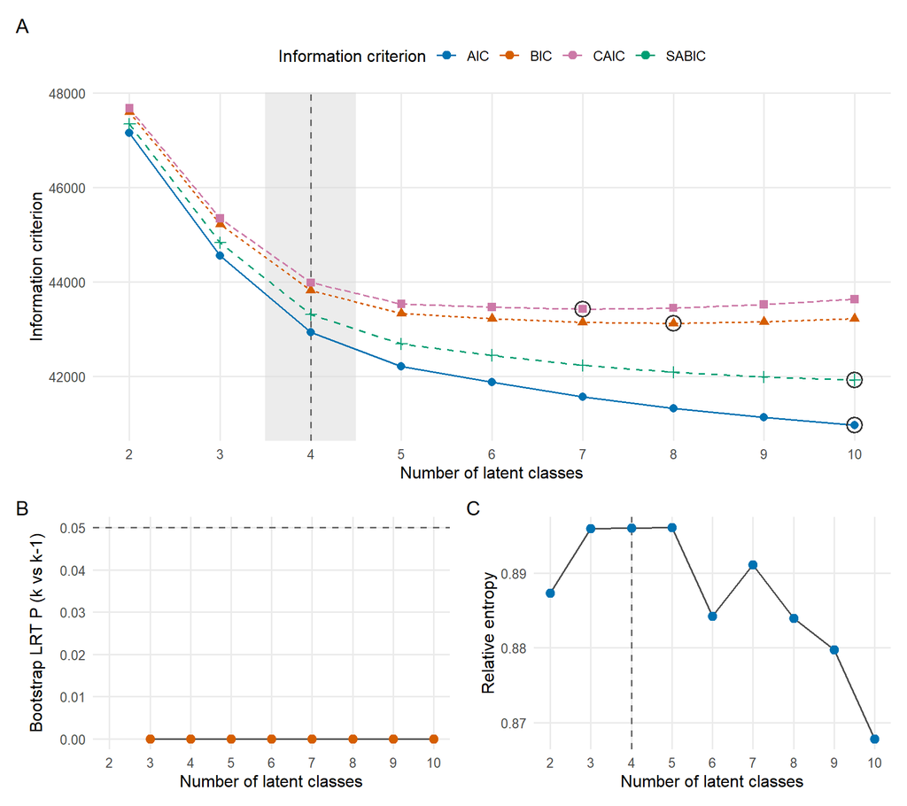

```r
okabe <- c(AIC = "#0072B2", BIC = "#D55E00", CAIC = "#CC79A7", SABIC = "#009E73")
retained <- 4

ic_long <- fit_tbl |>
  dplyr::select(Classes, AIC, BIC, CAIC, SABIC) |>
  tidyr::pivot_longer(-Classes, names_to = "Criterion", values_to = "value") |>
  dplyr::mutate(Criterion = factor(Criterion, levels = names(okabe)))
mins <- ic_long |> dplyr::group_by(Criterion) |> dplyr::slice_min(value, n = 1)

pA <- ggplot(ic_long, aes(Classes, value, colour = Criterion, shape = Criterion)) +
  annotate("rect", xmin = retained - .5, xmax = retained + .5, ymin = -Inf, ymax = Inf,
           fill = "grey85", alpha = .5) +
  geom_vline(xintercept = retained, linetype = "dashed", colour = "grey40") +
  geom_line(aes(linetype = Criterion), linewidth = .7) + geom_point(size = 2.4) +
  geom_point(data = mins, shape = 21, size = 4.6, stroke = .9, colour = "grey20", fill = NA) +
  scale_colour_manual(values = okabe) +
  scale_x_continuous(breaks = 2:10) +
  labs(x = "Number of latent classes", y = "Information criterion", colour = "Information criterion") +
  guides(shape = "none", linetype = "none") +
  theme_minimal(base_size = 12) +
  theme(legend.position = "top", panel.grid.minor = element_blank())

pB <- ggplot(fit_tbl, aes(Classes, `BLRT P`)) +
  geom_hline(yintercept = .05, linetype = "dashed", colour = "grey40") +
  geom_line(linewidth = .6, colour = "grey30") + geom_point(size = 2.6, colour = "#D55E00") +
  scale_x_continuous(breaks = 2:10) +
  labs(x = "Number of latent classes", y = "Bootstrap LRT P (k vs k-1)") +
  theme_minimal(base_size = 12) + theme(panel.grid.minor = element_blank())

pC <- ggplot(fit_tbl, aes(Classes, Entropy)) +
  geom_vline(xintercept = retained, linetype = "dashed", colour = "grey40") +
  geom_line(linewidth = .6, colour = "grey30") + geom_point(size = 2.6, colour = "#0072B2") +
  scale_x_continuous(breaks = 2:10) +
  labs(x = "Number of latent classes", y = "Relative entropy") +
  theme_minimal(base_size = 12) + theme(panel.grid.minor = element_blank())

fig1 <- pA / (pB | pC) + patchwork::plot_layout(heights = c(1.5, 1)) +
  patchwork::plot_annotation(tag_levels = "A")
fig1
```

```r
ggsave("Figure1_enumeration.png", fig1, width = 9, height = 8, dpi = 300, bg = "white")
```

## Four-class model — item-response probabilities (Table 3) and Figure 2

`item_meta` carries the English label and the behavior **type** for each item. Note **item 3** (`lid_des3`, the negatively worded laissez-faire item *“steers away from showing concern about results”*) is **excluded** from the LCA, so the measurement model and every figure below are built on the remaining 13 items.

```r
K <- 4
if (reuse_measurement) {
  post4 <- saved_measurement$post4
  rho <- saved_measurement$rho4
  class_labels <- saved_measurement$class_labels
  perm <- saved_measurement$class_permutation
  modal4 <- max.col(post4, ties.method = "first")
  sizes <- vapply(1:K, function(k) sum(d_lca$.w[modal4 == k]), numeric(1))
  sizes <- sizes/sum(sizes)
  stopifnot(nrow(post4) == nrow(d_lca))
} else {
g4 <- fits[[4]]
post4 <- get_post(g4)
modal4 <- max.col(post4, ties.method = "first")

## Guard: post4/modal4 must align row-for-row with d_lca (and the survey design
## and all covariate vectors). If glca dropped rows (e.g. concomitant NA), stop
## loudly instead of silently corrupting Tables 2 / S1 / S2 / S3.
stopifnot(nrow(post4) == nrow(d_lca))

## class sizes (weighted share)
sizes <- sapply(1:K, function(t) sum(d_lca$.w[modal4 == t])) ; sizes <- sizes / sum(sizes)

## Item-response probabilities rho: list over items, each K x 4 (categories).
get_rho <- function(g) {
  r <- g$param$rho
  if (is.list(r) && is.list(r[[1]])) r <- r[[1]]   # unwrap group level if present
  r
}
rho <- get_rho(g4)   # rho[[item]] is a K x 4 matrix (rows = class, cols = category)

## ── Canonical class ordering ──────────────────────────────────────────────────
## glca does not guarantee consistent class-index ordering across re-renders.
## We enforce a canonical ordering that is stable across runs:
##   C1 = Constructive       C2 = Passive/absent
##   C3 = Active constructive  C4 = Ambivalent/destructive
##
## Algorithm (item profiles only — no covariates, avoids circularity):
##   mean P(response ∈ {3,4}) across all 13 items per class:
##     minimum  → Passive/absent  (endorses nothing)
##     maximum  → Active constructive (endorses most)
##     2nd min  → Ambivalent/destructive (mixed; lower overall than constructive)
##     remaining → Constructive
m_top2 <- vapply(1:K, function(k)
  mean(sapply(rho, function(r) r[k, 3] + r[k, 4])), numeric(1))
k_PA <- which.min(m_top2)
k_AC <- which.max(m_top2)
rem  <- setdiff(1:K, c(k_PA, k_AC))
k_AD <- rem[which.min(m_top2[rem])]
k_C  <- setdiff(rem, k_AD)
perm <- c(k_C, k_PA, k_AC, k_AD)   # perm[i] = glca index for canonical slot i
class_labels <- c("C1 Constructive", "C2 Passive/absent",
                  "C3 Active constructive", "C4 Ambivalent/destructive")
cat("Canonical class mapping (glca index → canonical label):\n")
for (i in 1:4) cat(sprintf("  glca C%d (m_top2=%.3f) → %s\n",
                            perm[i], m_top2[perm[i]], class_labels[i]))
## Apply permutation to all class-indexed objects
post4  <- post4[, perm]
modal4 <- max.col(post4, ties.method = "first")                          # recompute from reordered posteriors
rho    <- lapply(rho, function(r) r[perm, , drop = FALSE])
sizes  <- sapply(1:K, function(t) sum(d_lca$.w[modal4 == t])); sizes <- sizes / sum(sizes)
cat("Class sizes after canonicalization:", paste(sprintf("%.1f%%", 100*sizes), collapse=", "), "\n")
}

## ---- item metadata (order = vars$items = lid_des1..14 WITHOUT lid_des3) --
## lid_des3 is excluded from the LCA (see the variable-mapping chunk), so it is
## intentionally absent here too; this table must stay aligned row-for-row with
## vars$items (13 rows) so rho[[j]] maps to the right item.
item_meta <- tibble::tribble(
  ~item,        ~label,                                          ~type,
  "lid_des1",   "Humiliates employees",                          "Destructive",
  "lid_des2",   "Encourages creative ideas",                     "Constructive",
  "lid_des4",   "Gestures of displeasure",                       "Destructive",
  "lid_des5",   "Avoids making decisions",                       "Laissez-faire",
  "lid_des6",   "Recognizes good performance",                   "Constructive",
  "lid_des7",   "Avoids involvement in work",                    "Laissez-faire",
  "lid_des8",   "Spreads false information",                     "Destructive",
  "lid_des9",   "Absent when needed",                            "Laissez-faire",
  "lid_des10",  "Berates by phone / rude email",                 "Destructive",
  "lid_des11",  "Seeks to develop capabilities",                 "Constructive",
  "lid_des12",  "Sets clear objectives",                         "Constructive",
  "lid_des13",  "Defines / explains tasks",                      "Constructive",
  "lid_des14",  "Flexible, open to innovation",                  "Constructive"
)

## ---- Table 3: probability of the top two categories (3 + 4) ------------
top2 <- t(vapply(seq_along(vars$items), function(j) rho[[j]][, 3] + rho[[j]][, 4], numeric(K)))
colnames(top2) <- paste0("C", 1:K)
tab3 <- dplyr::bind_cols(item_meta[, c("label","type")], as.data.frame(round(top2, 2)))

tab3 |>
  dplyr::transmute(`Leadership item` = paste0(label, " (", tolower(type), ")"),
                   C1, C2, C3, C4) |>
  knitr::kable("markdown", caption = "Table 3. Item-response probabilities (categories 3+4), four-class model.")
```

Table 3. Item-response probabilities (categories 3+4), four-class model.

| Leadership item | C1 | C2 | C3 | C4 |
| --- | --- | --- | --- | --- |
| Humiliates employees (destructive) | 0.02 | 0.02 | 0.02 | 0.08 |
| Encourages creative ideas (constructive) | 0.57 | 0.11 | 0.57 | 0.16 |
| Gestures of displeasure (destructive) | 0.10 | 0.05 | 0.09 | 0.14 |
| Avoids making decisions (laissez-faire) | 0.08 | 0.04 | 0.11 | 0.16 |
| Recognizes good performance (constructive) | 0.78 | 0.15 | 0.78 | 0.25 |
| Avoids involvement in work (laissez-faire) | 0.20 | 0.06 | 0.21 | 0.14 |
| Spreads false information (destructive) | 0.06 | 0.02 | 0.04 | 0.07 |
| Absent when needed (laissez-faire) | 0.08 | 0.05 | 0.09 | 0.17 |
| Berates by phone / rude email (destructive) | 0.06 | 0.01 | 0.02 | 0.06 |
| Seeks to develop capabilities (constructive) | 0.76 | 0.02 | 0.80 | 0.13 |
| Sets clear objectives (constructive) | 0.76 | 0.05 | 0.82 | 0.19 |
| Defines / explains tasks (constructive) | 0.95 | 0.09 | 0.96 | 0.28 |
| Flexible, open to innovation (constructive) | 0.89 | 0.08 | 0.95 | 0.18 |

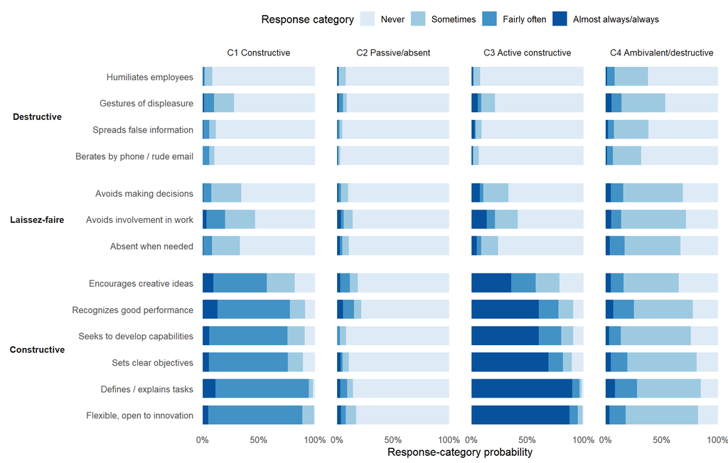

```r
cats <- c("Never","Sometimes","Fairly often","Almost always/always")
blue <- c("#DEEBF7","#9ECAE1","#4292C6","#08519C")

rho_long <- purrr::map_dfr(seq_along(vars$items), function(j) {
  m <- rho[[j]]                                   # K x 4
  tidyr::expand_grid(class = 1:K, cat = 1:4) |>
    dplyr::mutate(p = as.vector(t(m))[ (class-1)*4 + cat ],
                  item = item_meta$item[j])
}) |>
  dplyr::left_join(item_meta, by = "item") |>
  dplyr::mutate(
    type  = factor(type, levels = c("Destructive","Laissez-faire","Constructive")),
    label = factor(label, levels = rev(item_meta$label)),
    cat   = factor(cats[cat], levels = cats),
    class = factor(class_labels[class], levels = class_labels)
  )

fig2 <- ggplot(rho_long, aes(p, label, fill = cat)) +
  geom_col(width = .72) +
  facet_grid(type ~ class, scales = "free_y", space = "free_y", switch = "y") +
  scale_fill_manual(values = blue, name = "Response category") +
  scale_x_continuous(labels = scales::percent_format(accuracy = 1),
                     breaks = c(0, .5, 1), expand = expansion(mult = .04)) +
  labs(x = "Response-category probability", y = NULL) +
  theme_minimal(base_size = 12) +
  theme(legend.position = "top", panel.spacing.x = unit(1, "lines"),
        panel.grid = element_blank(), strip.placement = "outside",
        strip.text.y.left = element_text(face = "bold", angle = 0))
fig2
```

```r
ggsave("Figure2_itemprob.png", fig2, width = 11, height = 7, dpi = 300, bg = "white")
```

## Classification diagnostics — AvePP and OCC

For the retained four-class model, classification quality is summarised by the **average posterior probability** (AvePP) and the **odds of correct classification** (OCC). AvePP$_k$ is the mean posterior probability of class $k$ among the cases modally assigned to class $k$ (rule of thumb: AvePP $>$ .70 for every class). OCC$_k = [\text{AvePP}_k/(1-\text{AvePP}_k)] \big/ [\pi_k/(1-\pi_k)]$, where $\pi_k$ is the estimated class prevalence (mean posterior); OCC$_k > 5$ indicates good assignment (Nagin, 2005).

```r
Kd      <- ncol(post4)
pi_k    <- colMeans(post4)                                   # estimated prevalence
n_modal <- as.integer(table(factor(modal4, levels = 1:Kd)))  # modal class sizes
AvePP   <- vapply(1:Kd, function(k) mean(post4[modal4 == k, k]), numeric(1))
OCC     <- (AvePP / (1 - AvePP)) / (pi_k / (1 - pi_k))

class_diag <- tibble::tibble(
  Class               = paste0("C", 1:Kd),
  `n (modal)`         = n_modal,
  `pi_k (prevalence)` = round(pi_k, 3),
  AvePP               = round(AvePP, 3),
  OCC                 = round(OCC, 2)
)
class_diag |>
  knitr::kable("markdown",
    caption = "Classification diagnostics (four-class): average posterior probabilities (AvePP) and odds of correct classification (OCC).")
```

Classification diagnostics (four-class): average posterior probabilities (AvePP) and odds of correct classification (OCC).

| Class | n (modal) | pi_k (prevalence) | AvePP | OCC |
| --- | --- | --- | --- | --- |
| C1 | 458 | 0.251 | 0.927 | 37.66 |
| C2 | 302 | 0.163 | 0.952 | 100.80 |
| C3 | 522 | 0.280 | 0.952 | 51.68 |
| C4 | 565 | 0.307 | 0.940 | 35.37 |

All four profiles are assigned with high certainty: average posterior probabilities range 0.93 to 0.95 (all > .70), and odds of correct classification exceed 35 for every class, consistent with the high relative entropy (0.90). Classification error is therefore minimal.

## Medians (Q1–Q3) and Table 2 — survey-weighted profile characteristics

Continuous variables are summarized as survey-weighted median (Q1-Q3), and binary characteristics as survey-weighted percentages. Participant counts are unweighted. P-values are global comparisons across the four fixed modal classes: Rao-Scott F tests for binary characteristics and survey-adjusted Kruskal-Wallis rank tests for continuous characteristics. The latter compare ranks/distributions, not exclusively medians. SMD is the maximum absolute standardized mean difference among the six class pairs, using weighted means and class-specific variances. It is not a standardized difference of medians. These descriptive comparisons condition on modal classification and do not correct classification uncertainty.

```r
bin_vars <- c(
  "Unpaid care work at home -- yes" = "unpaid_care",
  "Did not complete secondary school" = "no_secondary",
  "Absence of union -- yes" = "no_union",
  "Workplace 1-10 workers" = "small_wp",
  "Customer-facing tasks -- no" = "customer_no",
  "Economic narrowness -- yes" = "econ_narrow",
  "Effort-reward imbalance -- yes" = "eri",
  "Sex -- women" = "sex_woman",
  "Hazardous alcohol use (AUDIT-C) -- yes" = "auditc_hazard",
  "Frequent negative acts (NAQ) -- yes" = "naq_frequent",
  "Self-labeled bullying (last 6 mo)" = "bully_self",
  "Sexual harassment (last 12 mo)" = "sex_harass")
table2 <- build_leadership_table2(dsn, modal4, post4, class_labels, bin_vars)
t2_full <- table2$full; t2_bin <- table2$binary; t2_cont <- table2$continuous
t2_full |> knitr::kable("html", caption = "Table 2. Survey-weighted characteristics by leadership profile.")
table2$class_sizes |> knitr::kable("html", digits = 3,
  caption = "Class-size audit: actual participants, sum of weights, weighted modal share, and model prevalence.")
```

Table 2. Survey-weighted characteristics by leadership profile.

| Characteristic | C1 | C2 | C3 | C4 | P | SMD |
| --- | --- | --- | --- | --- | --- | --- |
| Participants, unweighted n | 458 | 302 | 522 | 565 |  |  |
| Class share, survey-weighted % | 23.7 | 16.3 | 30.0 | 30.0 |  |  |
| Unpaid care work at home -- yes | 77.5 | 68.1 | 81.9 | 75.0 | <0.001 | 0.32 |
| Did not complete secondary school | 19.5 | 26.9 | 17.3 | 23.6 | 0.017 | 0.23 |
| Absence of union -- yes | 61.6 | 74.4 | 59.4 | 63.4 | 0.001 | 0.32 |
| Workplace 1-10 workers | 29.0 | 44.5 | 30.1 | 27.7 | <0.001 | 0.36 |
| Customer-facing tasks -- no | 36.8 | 39.9 | 30.5 | 34.5 | 0.082 | 0.20 |
| Economic narrowness -- yes | 19.9 | 29.3 | 28.1 | 33.2 | <0.001 | 0.30 |
| Effort-reward imbalance -- yes | 28.6 | 37.5 | 29.8 | 55.5 | <0.001 | 0.57 |
| Sex -- women | 36.7 | 47.0 | 38.6 | 41.6 | 0.059 | 0.21 |
| Hazardous alcohol use (AUDIT-C) -- yes | 30.0 | 23.0 | 23.4 | 30.2 | 0.042 | 0.16 |
| Frequent negative acts (NAQ) -- yes | 3.9 | 6.8 | 2.7 | 12.3 | <0.001 | 0.37 |
| Self-labeled bullying (last 6 mo) | 2.8 | 3.5 | 2.7 | 11.9 | <0.001 | 0.36 |
| Sexual harassment (last 12 mo) | 0.4 | 0.8 | 0.9 | 2.6 | 0.039 | 0.18 |
| Age, median (Q1-Q3), years | 43.0 (32.0-53.0) | 45.0 (32.0-56.0) | 41.0 (30.2-52.0) | 41.0 (32.0-51.4) | 0.240 | 0.16 |
| Job satisfaction, median (Q1-Q3) | 15.0 (14.0-17.0) | 14.0 (13.0-16.0) | 16.0 (14.0-18.0) | 14.0 (12.0-15.0) | <0.001 | 0.88 |

Class-size audit: actual participants, sum of weights, weighted modal share, and model prevalence.

|  | Class | class_label | n_modal | weight_sum | model_prevalence | weighted_percent |
| --- | --- | --- | --- | --- | --- | --- |
| Class 1 | C1 | C1 Constructive | 458 | 442.386 | 0.251 | 23.746 |
| Class 2 | C2 | C2 Passive/absent | 302 | 302.768 | 0.163 | 16.252 |
| Class 3 | C3 | C3 Active constructive | 522 | 558.952 | 0.280 | 30.003 |
| Class 4 | C4 | C4 Ambivalent/destructive | 565 | 558.863 | 0.307 | 29.999 |

*Notes.* Counts are unweighted; percentages and medians (Q1-Q3) are survey-weighted. The design uses weights only because strata and PSU identifiers are not mapped. For each variable, estimates exclude its missing values; the exported numeric summary gives every nonmissing denominator. Weighted quantiles retain midpoint weighted-ECDF interpolation from the original notebook. For a pair of classes, SMD = $(\mu_a-\mu_b)/\sqrt{(v_a+v_b)/2}$, where continuous $v$ is the survey estimate of population variance and binary $v=p(1-p)$. All six contrasts are exported, including signs. P-values are exploratory and are not multiplicity-adjusted. Unavailable tests are labeled “Not estimable” with a reason in the test export. See the [survey rank-test documentation](https://search.r-project.org/CRAN/refmans/survey/html/svyranktest.html).

## Table S1 — ML three-step odds ratios (reference = C1 Constructive)

One covariate at a time. Each row is the per-class OR (vs C1 Constructive) for a one-unit change in the covariate, from the from-scratch `ml3step()`.

```r
## cache OFF: ml3step is cheap (seconds), and a cached tableS1 would silently keep
## stale odds ratios if ml3step() or post4/modal4 change upstream (knitr cache keys
## only on this chunk's own code, not on upstream objects).

## covariates to model (label -> key); reference class is C1
or_vars <- c(
  "Effort-reward imbalance"        = "eri",
  "Hazardous alcohol use (AUDIT-C)"= "auditc_hazard",
  "Absence of union"               = "no_union",
  "Frequent negative acts (NAQ)"   = "naq_frequent",
  "Self-labeled bullying"          = "bully_self",
  "Sexual harassment"              = "sex_harass",
  "Female sex"                     = "sex_woman"
)

fit_or <- function(key) {
  ml3step(z = d_lca[[key]], post = post4, modal = modal4, sw = d_lca$.w)
}
ml_models <- lapply(or_vars, fit_or)

s1 <- purrr::imap_dfr(or_vars, function(key, lab) {
  m <- ml_models[[lab]]
  if (is.null(m)) stop("Missing ML model for ", key)
  fmt <- function(i) sprintf("%.2f (%.2f-%.2f)", m$ors$OR[i], m$ors$lo[i], m$ors$hi[i])
  tibble::tibble(Covariate = lab,
                 `C2 vs C1` = fmt(1), `C3 vs C1` = fmt(2), `C4 vs C1` = fmt(3))
})
s1 |> knitr::kable("markdown", caption = "Table S1. ML three-step odds ratios (95% CI), reference = C1.")
```

Table S1. ML three-step odds ratios (95% CI), reference = C1.

| Covariate | C2 vs C1 | C3 vs C1 | C4 vs C1 |
| --- | --- | --- | --- |
| Effort-reward imbalance | 1.57 (1.12-2.20) | 1.12 (0.82-1.52) | 3.57 (2.63-4.84) |
| Hazardous alcohol use (AUDIT-C) | 0.68 (0.47-0.97) | 0.69 (0.51-0.95) | 1.01 (0.74-1.37) |
| Absence of union | 1.88 (1.33-2.67) | 0.91 (0.69-1.20) | 1.08 (0.81-1.44) |
| Frequent negative acts (NAQ) | 1.96 (0.92-4.18) | 0.73 (0.32-1.68) | 4.03 (2.09-7.79) |
| Self-labeled bullying | 1.41 (0.51-3.90) | 1.15 (0.45-2.94) | 5.98 (2.67-13.39) |
| Sexual harassment | 2.46 (0.16-38.42) | 3.33 (0.27-41.21) | 9.85 (0.88-110.66) |
| Female sex | 1.58 (1.15-2.17) | 1.10 (0.83-1.46) | 1.25 (0.94-1.67) |

## Table S2 — Marginal predicted probabilities by covariate level

Predicted P(class | covariate) at *No* (z = 0) and *Yes* (z = 1), with parametric bootstrap 95% CIs and the difference Δ (pp), from the same ML three-step fits.

```r
cls_lab <- class_labels
set.seed(2125)  # Same intervals whether enumeration is reused or refitted.
margin_objects <- lapply(ml_models, ml3step_margins)
s2 <- purrr::imap_dfr(or_vars, function(key, lab) {
  m <- ml_models[[lab]]
  if (is.null(m)) return(NULL)
  mg <- margin_objects[[lab]]
  purrr::map_dfr(1:4, function(t) tibble::tibble(
    Covariate = ifelse(t == 1, lab, ""),
    Profile   = cls_lab[t],
    `No, % (95% CI)`  = sprintf("%.1f (%.1f-%.1f)", 100*mg$z0[2,t], 100*mg$z0[1,t], 100*mg$z0[3,t]),
    `Yes, % (95% CI)` = sprintf("%.1f (%.1f-%.1f)", 100*mg$z1[2,t], 100*mg$z1[1,t], 100*mg$z1[3,t]),
    `Delta (pp)`      = sprintf("%+.1f", 100*mg$delta[2,t])
  ))
})
s2 |> knitr::kable("markdown", caption = "Table S2. Marginal predicted probabilities by covariate level.")
```

Table S2. Marginal predicted probabilities by covariate level.

| Covariate | Profile | No, % (95% CI) | Yes, % (95% CI) | Delta (pp) |
| --- | --- | --- | --- | --- |
| Effort-reward imbalance | C1 Constructive | 28.2 (25.5-31.4) | 16.9 (14.1-20.4) | -11.3 |
|  | C2 Passive/absent | 16.6 (14.5-19.0) | 15.5 (12.8-18.7) | -1.1 |
|  | C3 Active constructive | 34.1 (31.3-36.9) | 22.8 (19.6-26.5) | -11.4 |
|  | C4 Ambivalent/destructive | 20.9 (18.5-23.5) | 44.5 (40.4-48.6) | +23.6 |
| Hazardous alcohol use (AUDIT-C) | C1 Constructive | 22.8 (20.3-25.5) | 26.8 (22.5-31.3) | +4.0 |
|  | C2 Passive/absent | 17.1 (15.0-19.4) | 13.6 (10.7-17.2) | -3.5 |
|  | C3 Active constructive | 31.3 (28.8-34.1) | 25.5 (21.9-29.8) | -5.8 |
|  | C4 Ambivalent/destructive | 28.6 (26.1-31.3) | 33.8 (29.3-38.6) | +5.3 |
| Absence of union | C1 Constructive | 25.3 (21.7-28.9) | 23.1 (20.6-25.8) | -2.1 |
|  | C2 Passive/absent | 11.1 (8.8-13.9) | 19.1 (16.8-21.7) | +8.1 |
|  | C3 Active constructive | 33.3 (29.7-37.2) | 27.7 (25.2-30.7) | -5.6 |
|  | C4 Ambivalent/destructive | 30.2 (26.6-34.1) | 29.9 (27.2-32.9) | -0.3 |
| Frequent negative acts (NAQ) | C1 Constructive | 24.7 (22.6-27.0) | 12.7 (7.4-21.7) | -11.9 |
|  | C2 Passive/absent | 16.1 (14.5-18.0) | 16.3 (10.3-24.2) | +0.2 |
|  | C3 Active constructive | 31.1 (29.0-33.4) | 11.6 (6.8-19.0) | -19.4 |
|  | C4 Ambivalent/destructive | 28.0 (25.8-30.3) | 58.2 (48.1-67.3) | +30.3 |
| Self-labeled bullying | C1 Constructive | 24.9 (22.8-27.4) | 9.6 (4.8-18.6) | -15.2 |
|  | C2 Passive/absent | 16.6 (14.8-18.5) | 9.4 (4.7-17.4) | -7.2 |
|  | C3 Active constructive | 30.7 (28.6-33.0) | 13.9 (8.3-22.6) | -16.8 |
|  | C4 Ambivalent/destructive | 27.7 (25.6-30.0) | 65.9 (54.4-75.1) | +38.2 |
| Sexual harassment | C1 Constructive | 24.2 (22.0-26.4) | 5.0 (0.5-35.4) | -18.9 |
|  | C2 Passive/absent | 16.3 (14.6-18.2) | 7.9 (1.7-27.9) | -8.4 |
|  | C3 Active constructive | 30.0 (27.9-32.3) | 20.9 (7.5-43.1) | -9.2 |
|  | C4 Ambivalent/destructive | 29.5 (27.2-31.9) | 60.2 (35.3-80.1) | +30.8 |
| Female sex | C1 Constructive | 25.5 (22.9-28.4) | 21.5 (18.4-24.9) | -4.0 |
|  | C2 Passive/absent | 14.2 (12.3-16.6) | 18.9 (16.2-22.0) | +4.7 |
|  | C3 Active constructive | 30.8 (27.8-33.7) | 28.5 (25.2-31.9) | -2.3 |
|  | C4 Ambivalent/destructive | 29.4 (26.5-32.5) | 31.1 (27.4-34.8) | +1.7 |

## Table S3 — Sensitivity analysis: naive vs BCH

This existing sensitivity uses unweighted estimates in both methods. For each binary covariate, the class-specific prevalence (and the mean of job satisfaction) under **naive modal assignment** versus **BCH** bias-adjustment. The maximum absolute naive–BCH discrepancy quantifies the impact of classification error (small when entropy is high).

```r
bch <- bch_setup(post4, modal4)

s3_vars <- c(
  "Effort-reward imbalance"        = "eri",
  "Self-labeled bullying"          = "bully_self",
  "Frequent negative acts (NAQ)"   = "naq_frequent",
  "Hazardous alcohol use (AUDIT-C)"= "auditc_hazard",
  "Absence of union"               = "no_union",
  "Sexual harassment"             = "sex_harass",
  "Female sex"                    = "sex_woman"
)

disc <- c()
s3 <- purrr::imap_dfr(s3_vars, function(key, lab) {
  x  <- d_lca[[key]]
  nv <- naive_class_mean(x, modal4) * 100
  bv <- bch_class_mean(x, bch$w)    * 100
  disc <<- c(disc, max(abs(nv - bv)))
  tibble::tibble(Covariate = lab,
    C1 = sprintf("%.1f / %.1f", nv[1], bv[1]), C2 = sprintf("%.1f / %.1f", nv[2], bv[2]),
    C3 = sprintf("%.1f / %.1f", nv[3], bv[3]), C4 = sprintf("%.1f / %.1f", nv[4], bv[4]))
})

## job satisfaction: mean (naive / BCH)
{
  js <- d_lca$job_sat
  nv <- naive_class_mean(js, modal4); bv <- bch_class_mean(js, bch$w)
  s3 <- dplyr::bind_rows(s3, tibble::tibble(Covariate = "Job satisfaction, mean",
    C1 = sprintf("%.1f / %.1f", nv[1], bv[1]), C2 = sprintf("%.1f / %.1f", nv[2], bv[2]),
    C3 = sprintf("%.1f / %.1f", nv[3], bv[3]), C4 = sprintf("%.1f / %.1f", nv[4], bv[4])))
}

cat(sprintf("Max absolute naive-BCH discrepancy: %.1f pp\n", suppressWarnings(max(disc))))
s3 |> knitr::kable("markdown", caption = "Table S3. Sensitivity: class-specific estimates (naive / BCH).")
```

```
Max absolute naive-BCH discrepancy: 2.0 pp
```

Table S3. Sensitivity: class-specific estimates (naive / BCH).

| Covariate | C1 | C2 | C3 | C4 |
| --- | --- | --- | --- | --- |
| Effort-reward imbalance | 27.1 / 25.1 | 36.4 / 35.5 | 29.7 / 29.4 | 56.5 / 57.8 |
| Self-labeled bullying | 3.1 / 2.5 | 4.0 / 3.5 | 3.5 / 3.4 | 12.3 / 12.8 |
| Frequent negative acts (NAQ) | 3.9 / 3.6 | 6.3 / 6.1 | 3.1 / 2.9 | 10.4 / 10.8 |
| Hazardous alcohol use (AUDIT-C) | 29.5 / 30.0 | 20.9 / 20.3 | 20.9 / 20.6 | 28.5 / 28.6 |
| Absence of union | 61.8 / 61.9 | 73.8 / 74.9 | 58.2 / 58.1 | 62.7 / 62.6 |
| Sexual harassment | 0.4 / 0.3 | 0.7 / 0.5 | 1.0 / 0.9 | 3.0 / 3.1 |
| Female sex | 48.3 / 47.9 | 55.3 / 55.6 | 49.4 / 49.4 | 53.3 / 53.4 |
| Job satisfaction, mean | 15.4 / 15.5 | 14.3 / 14.3 | 16.0 / 16.0 | 13.7 / 13.7 |

## Export tables and session info

```r
source("R/export_leadership_results.R")
export_leadership_results(environment())
```

```
Exported 19 CSV tables, private versioned results, public aggregate results, session info and SHA-256 manifest.
```